# Esfuerzo pesquero con cajas verdes y notas de venta

Taller 2026

## Objetivos

- Leer y depurar datos de cajas verdes (VMS GPS-GPRS de la flota artesanal andaluza)
- Unirlos con las notas de venta para asignar un arte a cada ping
- Identificar el estado de pesca con filtros de velocidad por arte
- Calcular el esfuerzo (horas de pesca) en una grilla 0.05° con código C-square
- Explorar los datos, mapear el esfuerzo y analizar las especies acompañantes del cerco

**Todos los datos del taller son simulados** (`data/simular_datos.R`). Mismo formato que los ficheros de la Junta de Andalucía, sin barcos, posiciones ni ventas reales.

## Programa

| Hora | Bloque |
| --- | --- |
| 09:00 | Presentación, datos y formato |
| 09:15 | Paquetes (`R/00_paquetes.R`) y simular los datos (`data/simular_datos.R`, ~5 min) |
| 09:30 | `01_load_CV.R` y `02_format_CV.R` |
| 10:10 | `exploratorio_cajas_verdes.R` y `exploratorio_notas_venta.R` |
| 10:40 | `03_join_CV_NV.R` y `exploratorio_cruce.R` |
| 11:10 | Pausa |
| 11:30 | `04_effort_grid.R` |
| 12:00 | `mapas_esfuerzo.R` |
| 12:30 | `especies_cerco.R` |
| 13:00 | Cierre |

## Flujo de trabajo

```
R/00_paquetes.R → data/simular_datos.R → data/raw/

data/raw/cajas_verdes/*.csv ─┐
                             ├─ 01 → CV_2021_2024_ZE.fst
                             ├─ 02 → CV_2021_2024_ZE_fmt.fst
data/raw/notas_venta/*.xlsx ─┼─ 03 → CV_NV_2021_2024_ZE.fst
                             └─ 04 → esfuerzo_2021_2024.fst
                                      ↓
   exploratorio_cajas_verdes (tras 02) · exploratorio_notas_venta
   exploratorio_cruce (tras 03) · mapas_esfuerzo · especies_cerco (tras 04)
```

- Cada script lee la salida del anterior desde `outputs/` (`.fst`)
- 01 y 02 en la misma sesión: el 02 usa `CV_all` en memoria
- Nombres de columnas en formato *tacsat* (VMStools / ICES WGSFD): `VE_REF`, `SI_LATI`, `SI_SPCA`…

## Paquetes y datos simulados

```r
source("R/00_paquetes.R")         # instala los que faltan y los carga
source("data/simular_datos.R")    # ~5 min, ~140 MB en data/raw/
```

`00_paquetes.R`:

```r
paquetes <- c("data.table", "fst", "tidyverse", "lubridate", "geosphere",
              "readxl", "writexl", "sf", "rnaturalearth", "rnaturalearthdata",
              "rmarkdown")
faltan <- paquetes[!paquetes %in% rownames(installed.packages())]
if (length(faltan) > 0) install.packages(faltan)
for (p in paquetes) library(p, character.only = TRUE)
```

## Datos

## Cajas verdes: formato bruto

Uno o varios CSV por año, separador `;`, BOM UTF-8, fecha `dd/mm/aaaa`:

```
## FECHA;HORA;CFPO;VELOCIDAD;LATITUD;LONGITUD;RUMBO;¿EN PUERTO?
## 01/01/2021;03:51:22;999034;0;37.18499;-7.33025;262.6;1
## 01/01/2021;03:53:53;999034;0.27;37.18491;-7.32988;338.6;1
## 01/01/2021;03:56:24;999034;0;37.18498;-7.33005;185.7;1
## 01/01/2021;03:58:56;999034;0;37.18502;-7.33019;267.9;1
## 01/01/2021;04:00:39;999032;0.3;37.18501;-7.33008;197.2;1
```

- `CFPO`: código del barco en el Censo de Flota Pesquera Operativa
- `VELOCIDAD` (nudos) y `RUMBO`: instantáneos, reportados por la caja
- `¿EN PUERTO?`: 1 si el ping está en puerto

## Notas de venta: formato bruto

Uno o varios xlsx por año, una fila por especie vendida y marea:

| ID_UDPROD | NOMBRE_UDPROD | FECHAVENTA | FAO | NOMBRE_ESPECIE | ARTE | TOTAL_KILOS | TOTAL_EUROS |
| --- | --- | --- | --- | --- | --- | --- | --- |
| ESP000999002 | SIMULADO 02 | 2021-01-01 | SVE | CHIRLA | RASTRA | 72.9 | 250.73 |
| ESP000999003 | SIMULADO 03 | 2021-01-01 | SVE | CHIRLA | RASTRA | 92.8 | 407.88 |
| ESP000999005 | SIMULADO 05 | 2021-01-01 | SVE | CHIRLA | RASTRA | 115.0 | 472.91 |
| ESP000999005 | SIMULADO 05 | 2021-01-01 | DON | COQUINA | RASTRA | 21.7 | 189.65 |
| ESP000999006 | SIMULADO 06 | 2021-01-01 | SVE | CHIRLA | DRAGAS MECANIZADAS (HIDRÁULICAS…) | 402.3 | 1431.74 |
| ESP000999011 | SIMULADO 11 | 2021-01-01 | OCC | PULPO | NASAS | 77.2 | 565.61 |

- `ID_UDPROD` = `"ESP"` + CFPO con 9 dígitos → clave para unir con las cajas
- `ARTE`: texto de la Junta → hay que recodificar a DCF (`LE_MET4`)

## 01 · Lectura

## `01_load_CV.R`: todos los ficheros, sin importar el nombre

```r
ficheros_cv <- list.files("data/raw/cajas_verdes", pattern = "\\.csv$", full.names = TRUE)

for (i in seq_along(ficheros_cv)) {
  dt <- fread(ficheros_cv[i], sep = ";", dec = ".", encoding = "UTF-8")
  dt <- dt[LATITUD  >= lat_min & LATITUD  <= lat_max &
           LONGITUD >= lon_min & LONGITUD <= lon_max]
  lista_cv[[i]] <- dt
}
CV_all <- rbindlist(lista_cv, use.names = TRUE, fill = TRUE)
CV_all[, ANYO := as.integer(substr(FECHA, 7, 10))]    # año desde la fecha
```

- Con datos reales basta copiar los CSV en `data/raw/cajas_verdes/`, se llamen como se llamen
- Filtrar la zona al leer reduce memoria y elimina pings con error de GPS (0, 0)

## 02 · Formato

## `02_format_CV.R`: velocidad e intervalo entre pings

```r
setorder(CV_all, VE_REF, SI_TIMESTAMP)
CV_all[, fecha_dia := as.Date(SI_TIMESTAMP, tz = "Europe/Madrid")]
CV_all[, `:=`(
  SI_DISTANCECA = c(NA, distHaversine(cbind(LONGITUD[-.N], LATITUD[-.N]),
                                      cbind(LONGITUD[-1],  LATITUD[-1]))),
  SI_TDIFF      = c(NA, as.numeric(diff(SI_TIMESTAMP), units = "secs"))
), by = .(VE_REF, fecha_dia)]
CV_all[, SI_SPCA := (SI_DISTANCECA / SI_TDIFF) * 1.94384]   # m/s → nudos
```

- Ordenar antes de calcular diferencias
- Agrupar por barco **y día**: no unir el último ping de un día con el primero del siguiente
- `FT_REF` = barco + día: es la “marea” que luego se cruza con las notas de venta

## Intervalo entre pings

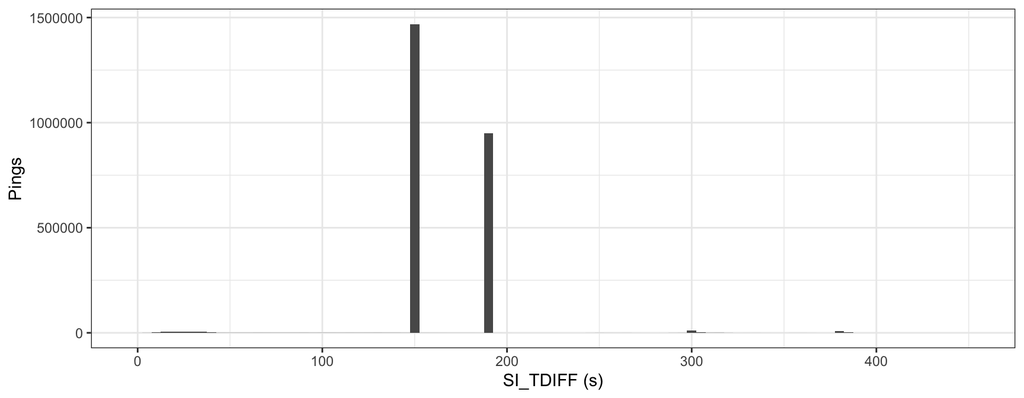

Dos tipos de caja (~150 s y ~190 s): casi todos los pings caen en dos barras.

## Intervalo entre pings (escala log)

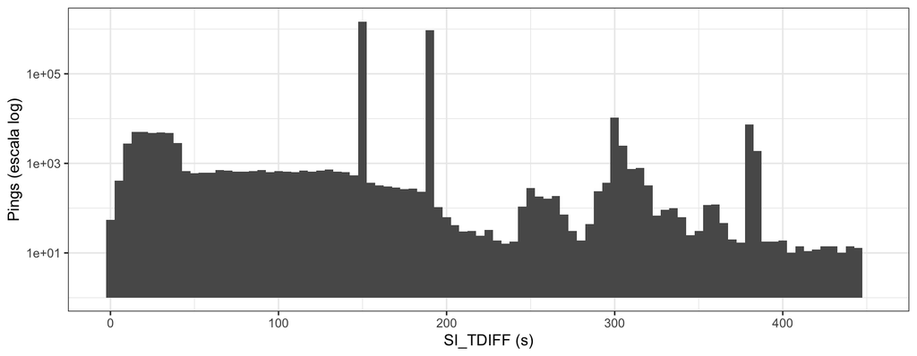

- 10–40 s: transmisiones muy seguidas → velocidades calculadas irreales
- ~300 y ~380 s: pings perdidos (2 × 151, 2 × 191); un Δt largo se suma entero como esfuerzo

## Velocidad calculada fuera de puerto

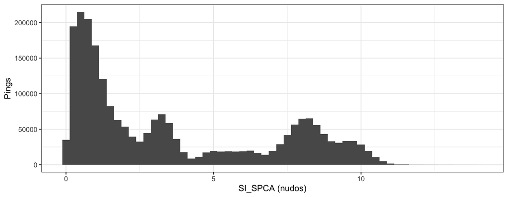

## 03 · Notas de venta

## `03_join_CV_NV.R`: una fila por marea

```r
arte_dominante <- NV_all[, .(TOTAL_KILOS_ARTE = sum(TOTAL_KILOS, na.rm = TRUE)),
                          by = .(FT_REF, ARTE)]
arte_dominante <- arte_dominante[order(FT_REF, -TOTAL_KILOS_ARTE)]
arte_dominante <- arte_dominante[, .SD[1], by = FT_REF]

CV_NV <- merge(CV_all, NV_key, by = "FT_REF", all.x = FALSE)   # inner join
```

- Se leen todos los xlsx de `data/raw/notas_venta/`; el año sale de `FECHAVENTA`
- Sin colapsar, cada ping se repite tantas veces como especies vendidas
- Arte dominante = el de más kilos en la marea
- Inner join: se pierden mareas sin nota de venta y notas sin caja verde

## Qué se pierde en el cruce

| conjunto | mareas |
| --- | --- |
| Mareas con caja verde | 13908 |
| Mareas con nota de venta | 13630 |
| Mareas en el cruce | 13212 |
| Caja verde sin nota de venta | 696 |
| Nota de venta sin caja verde | 418 |

Inner join por `FT_REF` (barco + día): solo quedan las mareas presentes en las dos fuentes.

## Recodificación del arte

```r
CV_NV[, LE_MET4 := fcase(
  grepl("RASTRA",                 ARTE, ignore.case = TRUE), "DRB",
  grepl("DRAGAS|HIDRA|HIDR.ULIC", ARTE, ignore.case = TRUE), "HMD",
  grepl("PALANGRES.*SIN ESPECIF", ARTE, ignore.case = TRUE), "LLSX",
  grepl("ARRASTRE",               ARTE, ignore.case = TRUE), "OTB",
  grepl("CERCO",                  ARTE, ignore.case = TRUE), "PS",
  ...
)]
```

| ARTE | LE_MET4 | pings |
| --- | --- | --- |
| RED DE ARRASTRE DE FONDO CON PUERTAS | OTB | 448475 |
| RED DE CERCO CON JARETA | PS | 308855 |
| PALANGRES (SIN ESPECIFICAR) | LLSX | 273165 |
| PALANGRES CALADOS | LLS | 269052 |
| REDES DE ENMALLE DE FONDO (CALADAS) | GNS | 267572 |
| NASAS | FPO | 221004 |
| TRASMALLOS | GTR | 213047 |
| RASTRA | DRB | 208982 |
| DRAGAS MECANIZADAS (HIDRÁULICAS…) | HMD | 189385 |

## 04 · Esfuerzo

## Velocidad por arte y límites de pesca

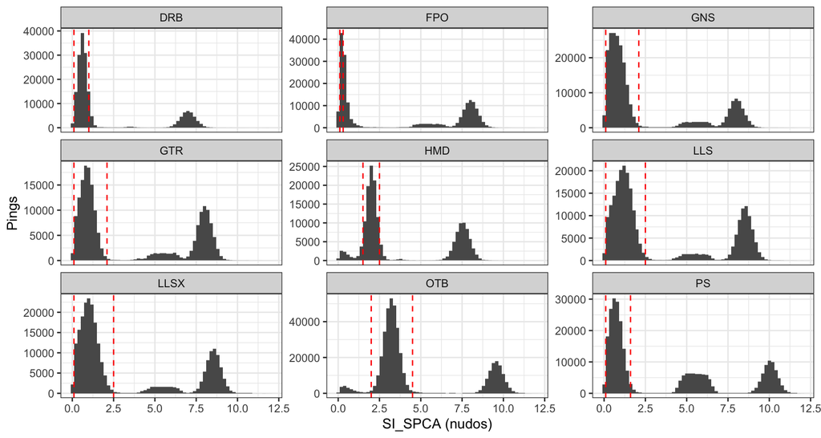

OTB (2.0–4.5) y PS (0.1–1.6): umbrales preliminares.

## `04_effort_grid.R`: selección de artes y estado de pesca

```r
artes_sel <- c("DRB", "HMD", "FPO", "GNS", "GTR", "LLS", "LLSX", "OTB", "PS")
# artes_sel <- "DRB"
CV_NV <- CV_NV[LE_MET4 %in% artes_sel]

CV_fil <- CV_NV[
  (LE_MET4 == "DRB"  & SI_SPCA >= 0.1 & SI_SPCA <= 1.0) |
  (LE_MET4 == "HMD"  & SI_SPCA >= 1.5 & SI_SPCA <= 2.5) |
  ...
  (LE_MET4 == "PS"   & SI_SPCA >= 0.1 & SI_SPCA <= 1.6)
]
```

## `04_effort_grid.R`: grilla y C-square

```r
res <- 0.05
CV_fil[, lon_cel := floor(SI_LONG / res) * res + res / 2]
CV_fil[, lat_cel := floor(SI_LATI / res) * res + res / 2]
centroides[, csq := csquare.cod(lon_cel, lat_cel, degrees = 0.05)]

esfuerzo_arte <- CV_fil[, .(horas_pesca = sum(SI_TDIFF, na.rm = TRUE) / 3600,
                            n_barcos    = uniqueN(VE_REF)),
                        by = .(lon_cel, lat_cel, csq, ANYO, LE_MET4)]
```

- Esfuerzo = Σ Δt de los pings en estado de pesca
- C-square: código estándar ICES para intercambiar datos por celda

## Esfuerzo por arte (2021–2024)

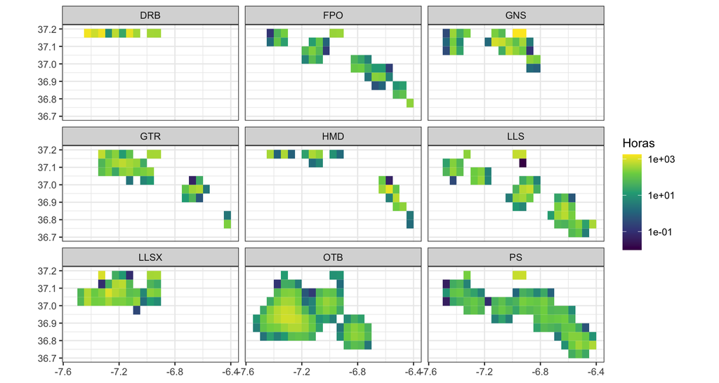

## Ejercicios

## Ejercicios

- `ejercicios/exploratorio_cajas_verdes.R`: pings, barcos y mareas por año, pings en puerto, Δt y velocidad
- `ejercicios/exploratorio_notas_venta.R`: artes declarados, especies, kg, euros y precios
- `ejercicios/exploratorio_cruce.R`: qué se pierde en el cruce; barcos, mareas, captura, duración y velocidad por arte
- `ejercicios/mapas_esfuerzo.R`: track de una marea y esfuerzo de un arte por año (con costa)
- `ejercicios/especies_cerco.R`: composición de la captura del cerco y distribución espacio-temporal de las especies acompañantes (reparto de la captura entre pings, como `splitAmongPings` de VMStools)

Correr por bloques; el arte o la especie se cambian en una variable al principio de cada bloque.

## Cierre

- El flujo 01–04 es el mismo que se aplica a los datos reales (~67 M pings)
- Con datos reales: copiar los ficheros en `data/raw/` y ajustar los años
- Puntos críticos: intervalos anómalos, umbrales de velocidad por arte, arte dominante por marea
- Siguientes pasos: caladeros principales (CFG 75 % / 90 %), centro de gravedad, tendencias por celda

Código: https://github.com/MauroMardones/Taller_Cajas_Verdes_2026